# Homework1

Christine Hou

2022-09-26

*Github url:* https://github.com/christinehou/STAT433_HW1

### Input Preparation

```r
library(tidyverse)
library(dbplyr)
library(nycflights13)
```

### 1. How many flights have a missing dep_time? What other variables are missing? What might these rows represent?

```r
sum(is.na(flights$dep_time))
```

```
[1] 8255
```

There are 8255 flights are missing.

```r
flights %>% filter(is.na(dep_time))
```

```
# A tibble: 8,255 × 19
    year month   day dep_time sched_de…¹ dep_d…² arr_t…³ sched…⁴ arr_d…⁵ carrier
   <int> <int> <int>    <int>      <int>   <dbl>   <int>   <int>   <dbl> <chr>
 1  2013     1     1       NA       1630      NA      NA    1815      NA EV
 2  2013     1     1       NA       1935      NA      NA    2240      NA AA
 3  2013     1     1       NA       1500      NA      NA    1825      NA AA
 4  2013     1     1       NA        600      NA      NA     901      NA B6
 5  2013     1     2       NA       1540      NA      NA    1747      NA EV
 6  2013     1     2       NA       1620      NA      NA    1746      NA EV
 7  2013     1     2       NA       1355      NA      NA    1459      NA EV
 8  2013     1     2       NA       1420      NA      NA    1644      NA EV
 9  2013     1     2       NA       1321      NA      NA    1536      NA EV
10  2013     1     2       NA       1545      NA      NA    1910      NA AA
# … with 8,245 more rows, 9 more variables: flight <int>, tailnum <chr>,
#   origin <chr>, dest <chr>, air_time <dbl>, distance <dbl>, hour <dbl>,
#   minute <dbl>, time_hour <dttm>, and abbreviated variable names
#   ¹sched_dep_time, ²dep_delay, ³arr_time, ⁴sched_arr_time, ⁵arr_delay
```

The flights with missing `dep_time`, the variables including `dep_delay`,`arr_time`,`arr_delay`,`air_time` are also missing. This actually means that these flights are cancelled by airlines.

### 2. Currently dep_time and sched_dep_time are convenient to look at, but hard to compute with because they’re not really continuous numbers. Convert them to a more convenient representation of number of minutes since midnight.

```r
flights = mutate(flights,
                   dep_time_minutes = dep_time %/% 100 * 60 + dep_time %% 100,
                   sched_dep_time_minutes = sched_dep_time %/% 100 * 60 + sched_dep_time %% 100)
select(flights, starts_with('dep_time'), starts_with('sched'))
```

```
# A tibble: 336,776 × 5
   dep_time dep_time_minutes sched_dep_time sched_arr_time sched_dep_time_minu…¹
      <int>            <dbl>          <int>          <int>                 <dbl>
 1      517              317            515            819                   315
 2      533              333            529            830                   329
 3      542              342            540            850                   340
 4      544              344            545           1022                   345
 5      554              354            600            837                   360
 6      554              354            558            728                   358
 7      555              355            600            854                   360
 8      557              357            600            723                   360
 9      557              357            600            846                   360
10      558              358            600            745                   360
# … with 336,766 more rows, and abbreviated variable name
#   ¹sched_dep_time_minutes
```

### 3. Look at the number of canceled flights per day. Is there a pattern? Is the proportion of canceled flights related to the average delay?

### Use multiple dyplr operations, all on one line, concluding with `ggplot(aes(x= ,y=)) + geom_point()`

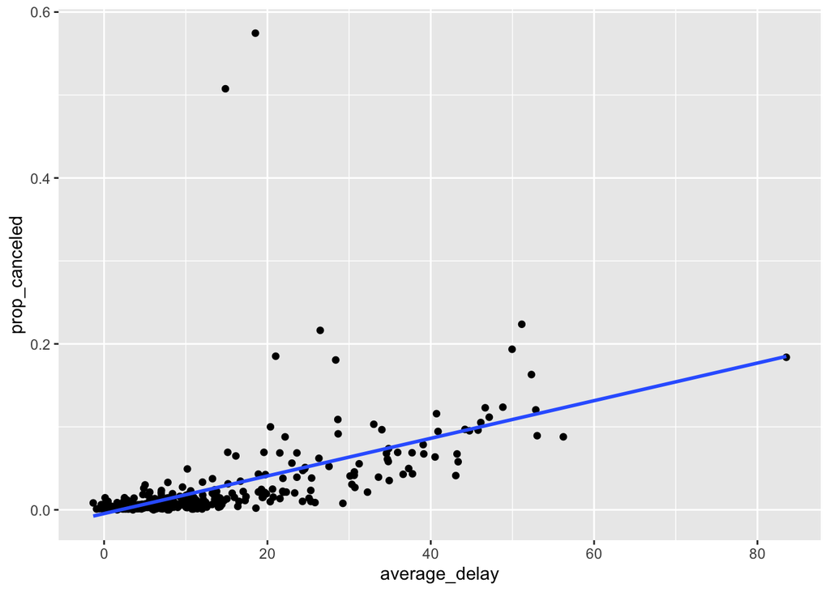

```r
flights %>% group_by(month, day) %>%
  summarize(average_delay = mean(dep_delay, na.rm = TRUE),
            prop_canceled = sum(is.na(dep_time)/n())) %>%
  ggplot(mapping = aes(x = average_delay, y =prop_canceled)) +
  geom_point() +
  geom_smooth(method = "lm", se = FALSE)
```

From the plot, we can see that the pattern is increasing, showing the positive relationship between proportion of canceled flights and average delay.